```python
import numpy as np
import matplotlib.pyplot as plt
%matplotlib inline
%config InlineBackend.figure_format = "retina"
from prettytable import PrettyTable
from matplotlib import rcParams
import emcee
import corner

rcParams["savefig.dpi"] = 100
rcParams["figure.dpi"] = 100
rcParams["font.size"] = 16
```

# Simplest example: fitting a line to data

(when you do not trust your error bars; otherwise: parameter optimization) Note: this example is based in the `emcee` tutorial.

### Simulating data:

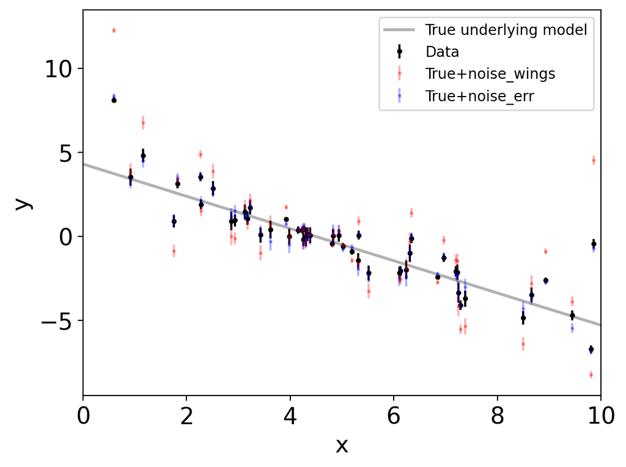

```python
import numpy as np
import matplotlib.pyplot as plt

np.random.seed(123)

# Choose the "true" parameters.
m_true = -0.9594  # slope
b_true = 4.294    # intercept
f_true = 0.534    # extra noise (systematics)

# Generate some synthetic data from the model.
N = 50
x = np.sort(10 * np.random.rand(N))
yerr = 0.1 + 0.5 * np.random.rand(N)
y = m_true * x + b_true

# Adding additional noise
ynoise_wings = np.abs(f_true * y) * np.random.randn(N)
ynoise_err   = yerr * np.random.randn(N)
y += ynoise_wings
y += ynoise_err

plt.errorbar(x, y, yerr=yerr, fmt=".k", markersize=5,label='Data')
plt.errorbar(x, y+ynoise_wings, yerr=yerr, fmt=".",markersize=3,c='red',alpha=0.3,label='True+noise_wings')
plt.errorbar(x, y+ynoise_err, yerr=yerr, fmt=".",markersize=3,c='blue',alpha=0.3,label='True+noise_err')
x0 = np.linspace(0, 10, 500)
plt.plot(x0, m_true * x0 + b_true, "k", alpha=0.3, lw=2,label='True underlying model')
plt.xlim(0, 10)
plt.legend(fontsize=10)
plt.xlabel("x")
plt.ylabel("y");
```

### Least-squares fit

Let's try the classical approach of minimization of the model-to-data distance:

```
Least-squares estimates:
m = -1.104 ± 0.016
b = 5.441 ± 0.091
---------------
True values:
m = -0.959
b = 4.294
```

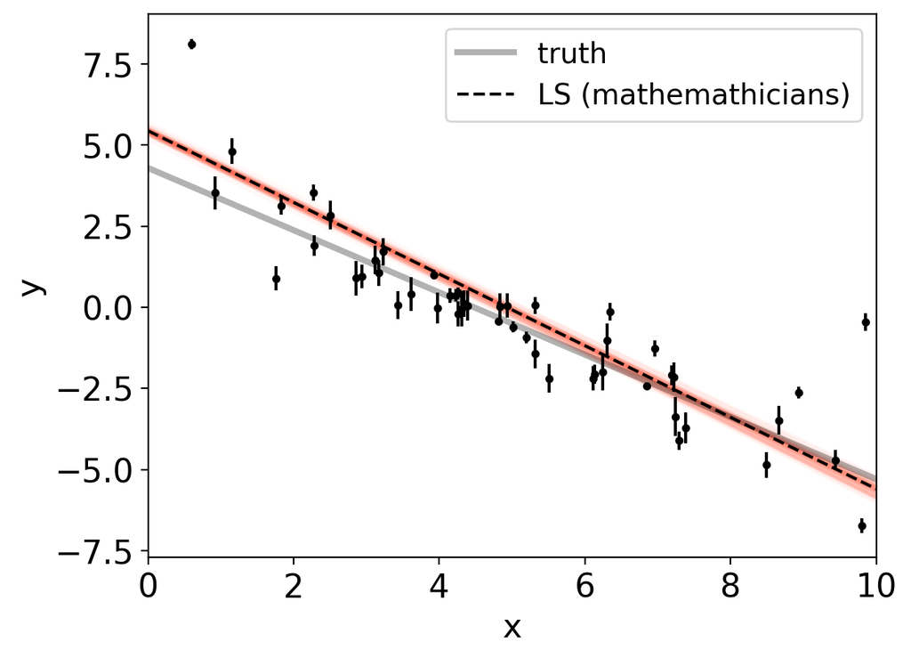

```python
# ==> Mathematic people
A = np.vander(x, 2)                         # Vandermonde matrix
ATA = np.dot(A.T, A / (yerr**2)[:, None])   #
cov = np.linalg.inv(ATA)                    # Covariance matrix
w = np.linalg.solve(ATA, np.dot(A.T, y / yerr**2))  # Algebraic solution

# ==> Print results
print("Least-squares estimates:")
print("m = {0:.3f} ± {1:.3f}".format(w[0], np.sqrt(cov[0, 0])))
print("b = {0:.3f} ± {1:.3f}".format(w[1], np.sqrt(cov[1, 1])))

# ==> Plot results
plt.errorbar(x, y, yerr=yerr, fmt=".k", capsize=0)
plt.plot(x0, m_true * x0 + b_true, "k", alpha=0.3, lw=3, label="truth")
plt.plot(x0, np.dot(np.vander(x0, 2), w), "--k", label="LS (mathemathicians)")
# Draw random samples from result
for i in range(100):
    _m = np.random.normal(loc=w[0],scale=np.sqrt(cov[0, 0]))
    _b = np.random.normal(loc=w[1],scale=np.sqrt(cov[1, 1]))
    plt.plot(x0,  _m * x0 + _b,alpha=0.04,c='tomato',zorder=-10)

print('---------------')
print("True values:")
print("m = {0:.3f}".format(m_true))
print("b = {0:.3f}".format(b_true))

plt.legend(fontsize=14)
plt.xlim(0, 10)
plt.xlabel("x")
plt.ylabel("y");
```

The results seem good but the error bars on the parameters seem underestimated given the large scatter of the data. This is because the least squares solution is the maximum likelihood result **for a model where the error bars are assumed correct, Gaussian and independent**. But this is (almost always) not the case.

### Maximum likelihood estimation

Let's instead try to maximize the likelihood function, which is a more flexible way to find the optimization of the parameters that maximize that funtion. This allows us to define the metric that we are interested in. In this case:

Our model is a simple straight line:

$y = mx + b$

The usual likelihood function used for continuous data is the Normal Likelihood:

$p(y|x,m,b,\sigma)=\displaystyle \prod_{i=1}^n \frac{1}{\sqrt{2\pi\sigma^2}}\exp\left(-\frac{(y_i-\mu)^2}{2\sigma^2}\right)$

By taking logarithms and introducing the model shape:

$\ln{p(y|x,m,b,\sigma)}= -\frac{1}{2} \displaystyle{\sum_{i=0}^{N}} \left[ \frac{(y_i-(b+m*x_i))^2}{s_i^2}+\ln{2 \pi s_i^2} \right] $

with:

$s_i^2 = \sigma_i^2 + f^2 (m x_i+b)^2$

Here, the $f_i$ term is a way to increase the uncertainty of the data as a function of the y-value. Typically, this is constant over the dataset and the equation is actually $s_i^2 = \sigma_i^2 + f^2$, where $f$ is called the jitter term.

```python
def log_likelihood(theta, x, y, yerr):
    """
        Log-likelihood function
        theta:    model parameters (\theta)
        x,y,yerr: data (D)
    """
    m, b, log_f = theta
    model = m * x + b
    sigma2 = yerr**2 + model**2 * np.exp(2 * log_f)
    return -0.5 * np.sum((y - model) ** 2 / sigma2 + np.log(2*np.pi*sigma2))
```

We now use the `scipy.optimize` to find the mset of parameters that maximize this function:

```
Maximum likelihood estimates:
m = -1.003
b = 4.528
f = 0.454
---------------
True values:
m = -0.959
b = 4.294
f = 0.534
```

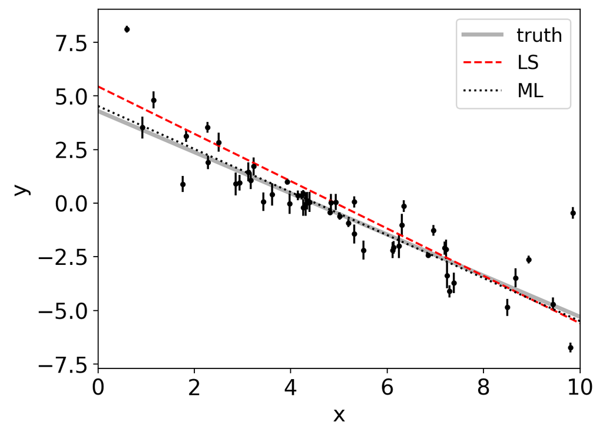

```python
from scipy.optimize import minimize

np.random.seed(42)
nll = lambda *args: -log_likelihood(*args)
initial = np.array([m_true, b_true, np.log(f_true)]) + 0.1 * np.random.randn(3)
soln = minimize(nll, initial, args=(x, y, yerr))
m_ml, b_ml, log_f_ml = soln.x

print("Maximum likelihood estimates:")
print("m = {0:.3f}".format(m_ml))
print("b = {0:.3f}".format(b_ml))
print("f = {0:.3f}".format(np.exp(log_f_ml)))
print('---------------')
print("True values:")
print("m = {0:.3f}".format(m_true))
print("b = {0:.3f}".format(b_true))
print("f = {0:.3f}".format(f_true))

plt.errorbar(x, y, yerr=yerr, fmt=".k", capsize=0)
plt.plot(x0, m_true * x0 + b_true, "k", alpha=0.3, lw=3, label="truth")
plt.plot(x0, np.dot(np.vander(x0, 2), w), "--r", label="LS")
plt.plot(x0, np.dot(np.vander(x0, 2), [m_ml, b_ml]), ":k", label="ML")

plt.legend(fontsize=14)
plt.xlim(0, 10)
plt.xlabel("x")
plt.ylabel("y");
```

The problem now: **how do we estimate the uncertainties on m and b**? What’s more, we probably don’t really care too much about the value of $f$ but it seems worthwhile to **propagate any uncertainties about $f$ to our final estimates of m and b**. This is where MCMC comes in.

### Monte Carlo Markov Chain (MCMC)

From the theory part of this talk we saw that the posterior distribution is proportional to the likelihood times the prior knowledge:

$p(M,\boldsymbol{\theta}|D,I) \propto p(D|M,\boldsymbol{\theta},I)\times p(M,\boldsymbol{\theta}|I)$

or with the current notation:

$p(b,m,f|x,y,\sigma) \propto p(y|x,m,b,\sigma) \times p(m,b,f)$

We already defined the likelihood function above, now we need to define the prior component $p(m,b,f)$. This encapsulates any previous knowledge on the parameters, e.g., results from other experiments, physically acceptable ranges, etc.

This is critical because the MCMC will draw samples allowed by this prior knowledge, defined as a probability distribution.

For example, for the slope:

$p(m) = \begin{cases} 1/6 & \text{if } -5<m<1 \\ 0 & {\rm otherwise} \end{cases}$

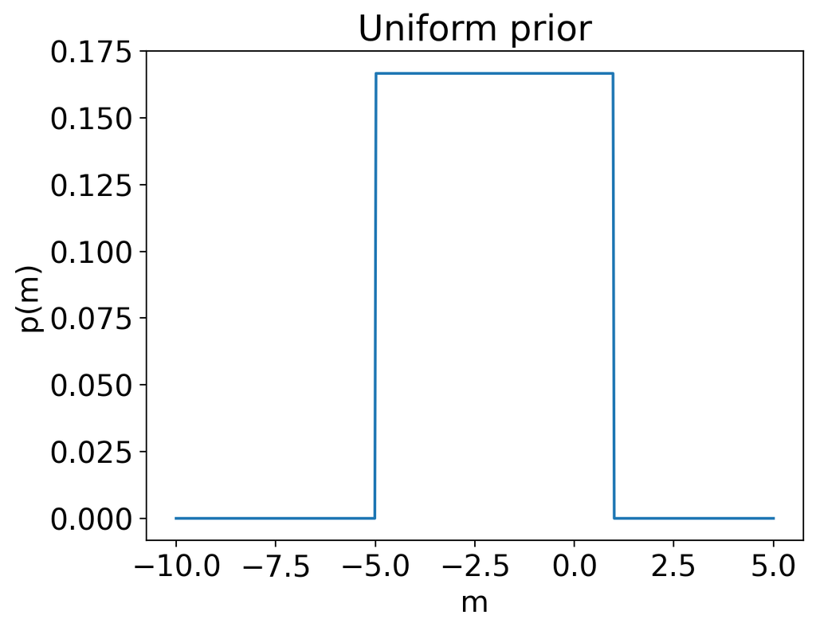

```python
def p(m):
    return np.where((-5 < m) & (m < 1), 1/6, 0)
m_vals = np.linspace(-10, 5, 500)
p_vals = p(m_vals)
plt.plot(m_vals, p_vals)
plt.xlabel("m")
plt.ylabel("p(m)")
plt.title("Uniform prior")
plt.show()
```

```python
def log_prior(theta):
    m, b, log_f = theta
    p_prior = 0
    if ((-5.0 < m < 1) & \
        ( 0.0 < b < 10.0) & \
        (-10.0 < log_f < 1.0)):
        p_prior += 1/6 + 1/10 + 1/11
        return np.log(p_prior)
    else:
        return -np.inf
```

Now we only define the posterior probability as the sum of the log-prior and log-likelihood results:

```python
def log_probability(theta, x, y, yerr):
    lp = log_prior(theta)
    if not np.isfinite(lp):
        return -np.inf
    loglike = log_likelihood(theta, x, y, yerr)
    return lp + loglike
```

Now we define the properties of the MCMC run:

```python
# MCMC properties:
ndim     = 3       # Dimension of the problem (number of parameters)
nwalkers = 4*ndim  # Number of walkers (simultaneous chains)
nsteps   = 30000    # Number of steps (iterations) per walker
pnames   = ['m','b','log_f']

# Initial guess around the max-likelihood solution [optional - otherwise a random array within priors]
p0 = np.zeros((nwalkers,ndim))
for ii in range(ndim):
    if pnames[ii] == 'm': minim,maxim = -5.0, 1
    if pnames[ii] == 'b': minim,maxim =  0.0, 10
    if pnames[ii] == 'log_f': minim,maxim = -10.0, 1

    for jj in range(nwalkers):
        p0[jj][ii] = np.random.uniform(minim,maxim,1)

# [Optional to improve efficiency: set p0 around the max-likelihood solution]:
#p0 = soln.x + 1e-4 * np.random.randn(nwalkers, ndim)


# Define the Sampler:
sampler = emcee.EnsembleSampler(nwalkers, ndim, log_probability, args=(x, y, yerr))

# Run the MCMC
sampler.run_mcmc(p0, nsteps, progress=True);
```

ok, let's take a look at how the chains behaved:

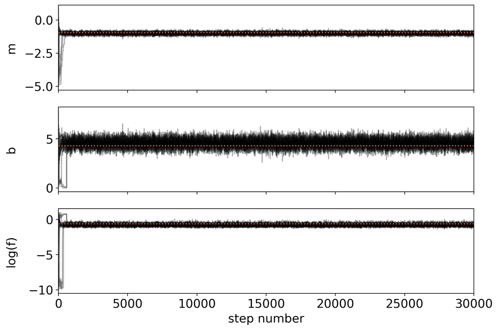

```python
fig, axes = plt.subplots(3, figsize=(10, 7), sharex=True)
samples = sampler.get_chain()
labels = ["m", "b", "log(f)"]
for i in range(ndim):
    ax = axes[i]
    ax.plot(samples[:, :, i], "k", alpha=0.3)
    ax.set_xlim(0, len(samples))
    ax.set_ylabel(labels[i])
    ax.yaxis.set_label_coords(-0.1, 0.5)
    if i  == 0: ax.axhline(m_true,ls=':',c='tomato')
    if i  == 1: ax.axhline(b_true,ls=':',c='tomato')
    if i  == 2: ax.axhline(np.log(f_true),ls=':',c='tomato')

axes[-1].set_xlabel("step number");
```

Now we can check how well mixed are the chains by checking the autocorrelation time ($\tau$) of the chains for each parameter. $\tau$ is the number of steps that are needed before the chain “forgets” where it started.

```python
table = PrettyTable()

burning = 5000  # Discards the first N steps of each walker

tau = sampler.get_autocorr_time(discard=burning, c=5, tol=10, quiet=True)
print('\n=========================')
print('Autocorrelation times:')
print('=========================')
table.field_names = ["parameter", "tau (in steps)", "Chain length (in multiples of tau)"]
for i, name in enumerate(pnames):
    table.add_row([name, np.round(tau[i],1), np.round((nsteps-burning) / tau[i],1) ])
print(table)
```

```
=========================
Autocorrelation times:
=========================
+-----------+----------------+------------------------------------+
| parameter | tau (in steps) | Chain length (in multiples of tau) |
+-----------+----------------+------------------------------------+
|     m     |      42.8      |               583.6                |
|     b     |      42.2      |               592.5                |
|   log_f   |      42.9      |               582.4                |
+-----------+----------------+------------------------------------+
```

The chain length is > 50 times the autocorrelation time for each of the parameters --> CONVERGENCE reached!

#### MCMC Results

Let's now check the results. We first collapse all $n_{\rm walkers}$ chains into a single chain to get all chains together.

```python
flat_samples = sampler.get_chain(discard=5000, thin=15, flat=True)
print(flat_samples.shape)
```

```
(19992, 3)
```

And plot the 1D (marginalised) and 2D projections of the posterior probability distributions of your parameters.

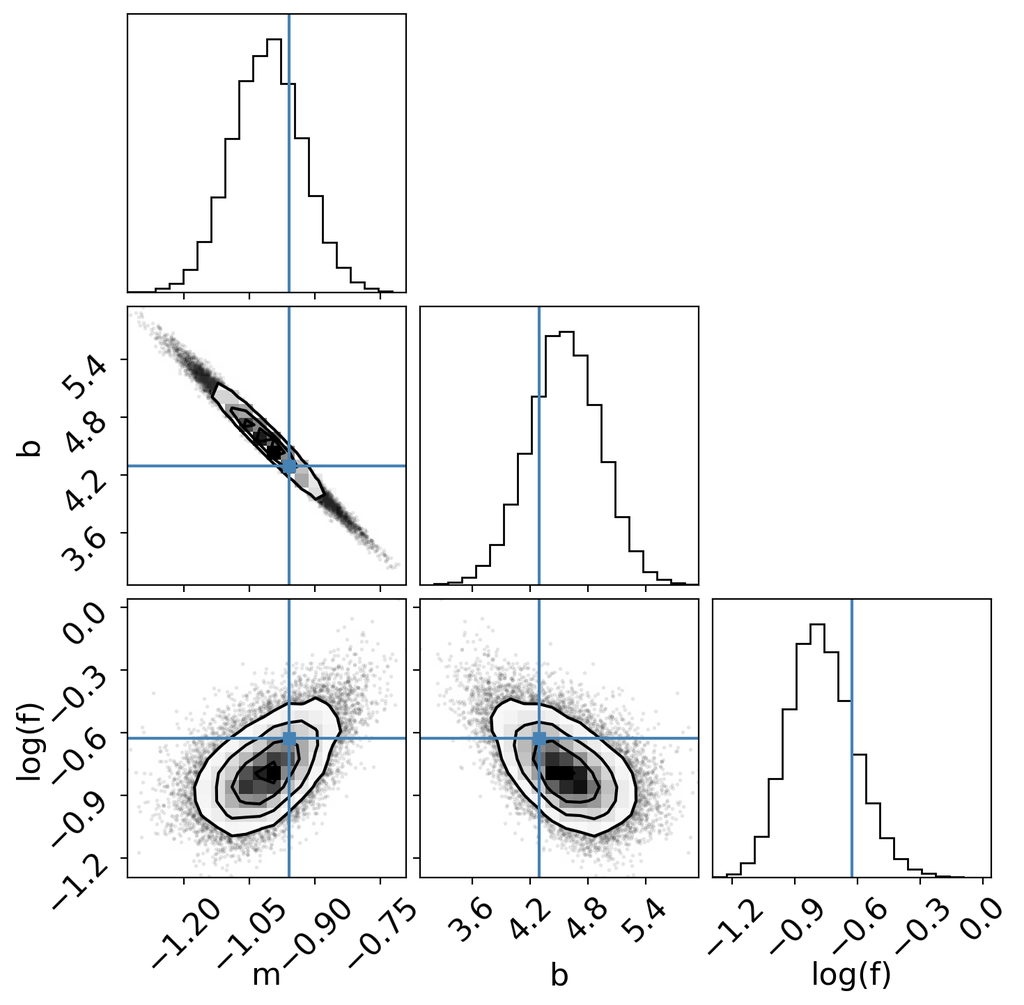

```python
fig = corner.corner(
    flat_samples, labels=labels, truths=[m_true, b_true, np.log(f_true)]
)
```

And the corresponding inferred parameters and confidence intervales are:

```python
from IPython.display import display, Math

for i in range(ndim):
    mcmc = np.percentile(flat_samples[:, i], [16, 50, 84])
    q = np.diff(mcmc)
    txt = "\mathrm{{{3}}} = {0:.3f}_{{-{1:.3f}}}^{{{2:.3f}}}"
    txt = txt.format(mcmc[1], q[0], q[1], labels[i])
    display(Math(txt))
print('---------------')
print("True values:")
print("m = {0:.3f}".format(m_true))
print("b = {0:.3f}".format(b_true))
print("f = {0:.3f}".format(f_true))
```

$\displaystyle \mathrm{m} = -1.009_{-0.081}^{0.080}$

$\displaystyle \mathrm{b} = 4.557_{-0.364}^{0.368}$

$\displaystyle \mathrm{log(f)} = -0.779_{-0.147}^{0.168}$

```
---------------
True values:
m = -0.959
b = 4.294
f = 0.534
```

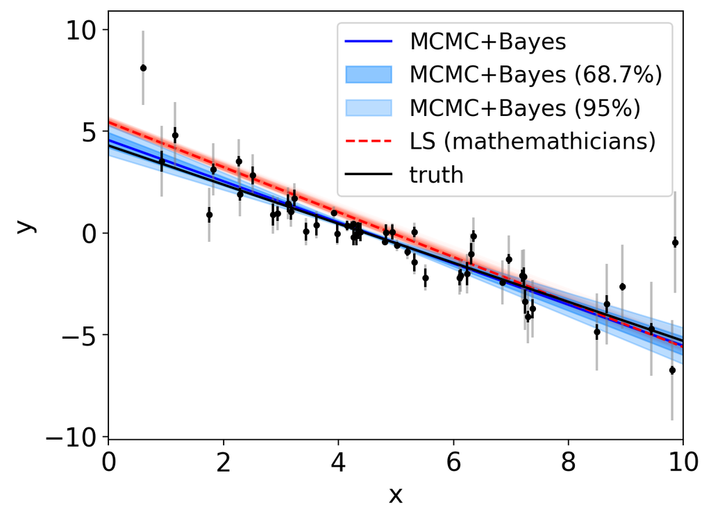

```python
# Draw random samples from result
ymall = []
for s in flat_samples[np.random.randint(len(flat_samples), size=1000)]:
    ymall.append(s[0] * x0 + s[1])
ymall = np.array(ymall)
mu, sig1 = ymall.mean(0), 1 * ymall.std(0)
plt.plot(x0,mu,c='blue',label='MCMC+Bayes')
plt.fill_between(x0,mu-sig1,mu+sig1,color='dodgerblue',alpha=0.5,label=r'MCMC+Bayes (68.7%)')
plt.fill_between(x0,mu-2*sig1,mu+2*sig1,color='dodgerblue',alpha=0.3,label=r'MCMC+Bayes (95%)')


for i in range(100):
    _m = np.random.normal(loc=w[0],scale=np.sqrt(cov[0, 0]))
    _b = np.random.normal(loc=w[1],scale=np.sqrt(cov[1, 1]))
    plt.plot(x0,  _m * x0 + _b,alpha=0.04,c='tomato',zorder=-10)
plt.plot(x0, np.dot(np.vander(x0, 2), w), "--r", label="LS (mathemathicians)")

mcmc_m = np.percentile(flat_samples[:, 0], [16, 50, 84])[1]
mcmc_b = np.percentile(flat_samples[:, 1], [16, 50, 84])[1]
mcmc_logf = np.percentile(flat_samples[:, 2], [16, 50, 84])[1]
plt.errorbar(x, y, yerr=np.sqrt(yerr**2+np.exp(mcmc_logf)**2*(mcmc_b+mcmc_m*x)**2), fmt=".",c='gray', capsize=0,alpha=0.5)
plt.errorbar(x, y, yerr=yerr, fmt=".k", capsize=0)
plt.plot(x0, m_true * x0 + b_true, "k", label="truth")
plt.legend(fontsize=14)
plt.xlim(0, 10)
plt.xlabel("x")
plt.ylabel("y");
```

# A real example: discovering the first exoplanet

Recipe for a Bayesian-driven modeling of your data with `emcee`:

1. Prepare your data $\mathcal{D}$ (get basic properties)
2. Define the model to test ($\mathcal{M}$) and metric to test → log-likelihood function
3. Define your priors → log-prior function
4. Set your log-probability function
5. Define the `emcee` properties for the MCMC run (N$_{\rm walkers}$, N$_{\rm steps}$ per walker, initial position)
6. Run MCMC
7. Check convergenge → autocorrelation time vs. chain length + **chain plot**
8. Check parameter degeneracies → **corner plot**
9. Obtain **final parameter inferences** from marginalised posteriors
10. Publish paper → Get the Nobel Prize

#### Data preparation [step 1]

```python
# Read the RV time series from ELODIE
data = np.genfromtxt('51peg.rv',dtype=None,encoding='utf-8')
time = data[:,0]  # BJD-2400000 [days]
rv   = data[:,1]  # [m/s]
erv  = data[:,2]  # [m/s]
```

```python
# Basic properties:
TimeSpan = np.max(time) - np.min(time)
MeanCad  = np.mean(time[1:]-time[0:-1])
MedCad   = np.median(time[1:]-time[0:-1])
RVspan   = np.max(rv) - np.min(rv)
RVmean   = np.mean(rv)
MedRVerr = np.median(erv)
```

```python
# Show properties:
table = PrettyTable()
table.field_names = ["Property", "Value","Units"]
table.align = "r"
table.add_row(["Time span", np.floor(TimeSpan),"days"])
table.add_row(["Mean Cadence", np.round(MeanCad,2),"days"])
table.add_row(["Median Cadence", np.round(MedCad*24*60,2),"min"],divider=True)
table.add_row(["RV mean", RVmean,"m/s"])
table.add_row(["RV span", RVspan,"m/s"])
table.add_row(["Median eRV", MedRVerr,"m/s"])
print(table)
```

```
+----------------+------------+-------+
|       Property |      Value | Units |
+----------------+------------+-------+
|      Time span |     2187.0 |  days |
|   Mean Cadence |       8.58 |  days |
| Median Cadence |      43.07 |   min |
+----------------+------------+-------+
|        RV mean | -5.4515625 |   m/s |
|        RV span |      143.5 |   m/s |
|     Median eRV |        6.4 |   m/s |
+----------------+------------+-------+
```

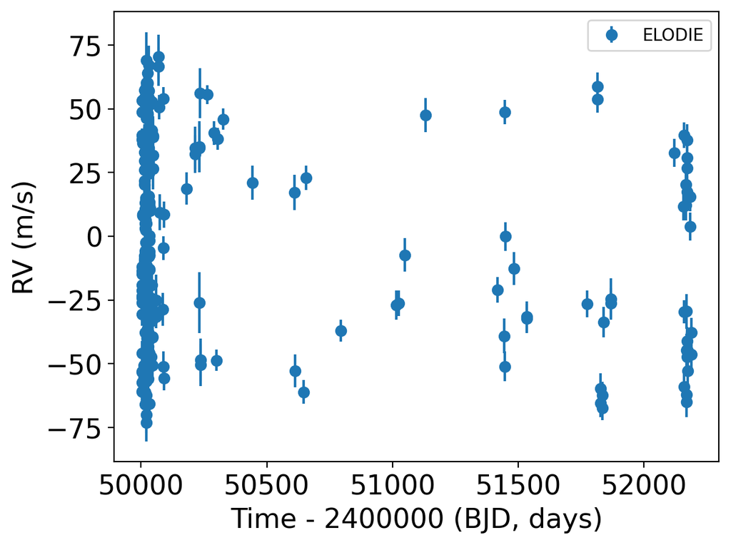

```python
# Display the RV time series
plt.errorbar(time,rv,erv,fmt='o',label='ELODIE')
plt.legend(fontsize=10)
plt.xlabel('Time - 2400000 (BJD, days)')
plt.ylabel('RV (m/s)')
```

```
(50000.0, 50040.0)
```

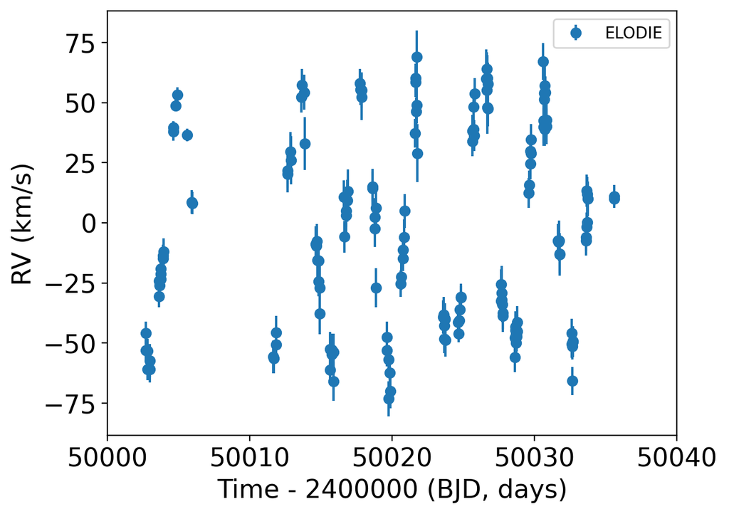

```python
# Display the RV time series
plt.errorbar(time,rv,erv,fmt='o',label='ELODIE')
plt.legend(fontsize=10)
plt.xlabel('Time - 2400000 (BJD, days)')
plt.ylabel('RV (km/s)')
plt.xlim(50000,50040)
```

```
(array([4.37408437e+03, 3.64507031e+03, 3.12434598e+03, ...,
        1.49540221e-02, 1.49540119e-02, 1.49540017e-02]),
 array([0.01574591, 0.0168294 , 0.01829695, ..., 0.03358226, 0.02409585,
        0.0141024 ]),
 4.231074070419806,
 array([0.10578219, 0.11085614, 0.12223928]),
 <Axes: xlabel='Period (days)', ylabel='Power'>)
```

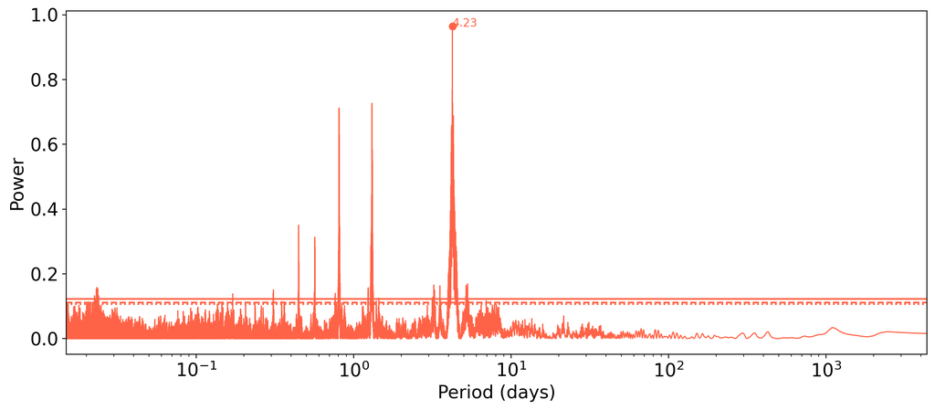

```python
# Preliminary analysis of the data through a GLS periodogram
import sci_utils as su
su.plot_periodogram(time,rv,erv)
```

#### Define the functions for the MCMC sampling [steps 2-4]

Our model includes the Keplerian signal and a jitter term:

$\mathcal{D}_i(t) = \mathcal{M}_i(t) + \mathcal{J}_i(t)$

where the model $\mathcal{M}_i(t)$ in this case is a Keplerian signal in the form:

$\mathcal{M}(t) = RV(t) = V_{\rm sys} + K\cos{[2\pi(t-T_0)/P + \pi/2]}$

```python
def log_likelihood(theta):
    """
        Log-likelihood function
        theta:    model parameters
        x,y,yerr: data (D)
    """
    Vsys,K,period,T0,RVjitter = theta
    phase = ((time-T0) % period)/ period
    RVmodel = Vsys + K * np.cos(2.*np.pi*phase+np.pi/2)
    RVjitter = np.exp(RVjitter)
    sigma = np.sqrt(erv**2+RVjitter**2)
    residuals = (rv-RVmodel)

    loglike = -0.5*len(time)*np.log(2*np.pi) - \
                np.sum( np.log(sigma**2) + residuals**2/(2*sigma**2) )

    return loglike
```

```python
def log_prior(theta):
    """
        Log-prior function
        theta:    model parameters
    """
    p_prior = np.zeros(len(theta))
    for ii,param in enumerate(pdict.items()):
        pname,prop = param
        if prop['type'] == 'U':
            if prop['min'] < theta[ii] < prop['max']:
                p_prior[ii] = np.log(1/(prop['max']-prop['min']))
        elif prop['type'] == 'LU':
            if np.log(prop['min']) < theta[ii] < np.log(prop['max']):
                p_prior[ii] = np.log(1/(np.log(prop['max'])-np.log(prop['min'])))

        if p_prior[ii] == 0:
            return -np.inf

    return np.sum(p_prior)
```

```python
def log_probability(theta):
    """
        Log-probability function
        theta:    model parameters
        x,y,yerr: data (D)
    """
    # log-PRIOR:
    lp = log_prior(theta)
    if not np.isfinite(lp):
        return -np.inf

    # log-LIKELIHOOD:
    loglike = log_likelihood(theta)

    # log-POSTERIOR
    return lp + loglike
```

#### Define MCMC properties [step 5]

```python
# Parameters:
global pdict,time,rv,erv
pdict = {'Vsys'  :{'type':'U','min':RVmean-RVspan,'max':RVmean+RVspan},
         'K'     :{'type':'U','min':0,'max':RVspan},
         'period':{'type':'U','min':MedCad,'max':40},
         'T0'    :{'type':'U','min':np.min(time),'max':np.min(time)+40},
         'RVjit' :{'type':'LU','min':0.01,'max':2*MedRVerr},
        }

# MCMC properties:
pnames   = np.array(list(pdict.keys()))
ndim     = len(pnames) # Dimension of the problem (number of parameters)
nwalkers = 4*ndim      # Number of walkers (simultaneous chains)
nsteps   = 50000       # Number of steps (iterations) per walker

# Initial guess at a random position of the parameter space within the prior range:
p0 = np.zeros((nwalkers,ndim))
for ii,param in enumerate(pdict.items()):
    pname,prop = param
    for jj in range(nwalkers):
        if prop['type'] == 'U' : p0[jj][ii] = np.random.uniform(prop['min'],prop['max'])
        if prop['type'] == 'LU': p0[jj][ii] = np.exp(np.random.uniform(np.log(prop['min']),np.log(prop['max'])))
        if prop['type'] == 'G' : p0[jj][ii] = np.random.normal(prop['mu'],prop['sig'])
```

#### Run MCMC [step 6]

##### Let's first sample the parameter space blindly

```python
sampler = emcee.EnsembleSampler(nwalkers, ndim, log_probability)
p0, lnp, _ = sampler.run_mcmc(p0, nsteps, progress=True)
```

```
  lnpdiff = f + nlp - state.log_prob[j]
```

```python
# Evolution of the chains
def plot_chains(sampler,burning=0):
    pnames = np.array(list(pdict.keys()))
    fig, axes = plt.subplots(len(pnames), figsize=(10, 7), sharex=True)
    samples = sampler.get_chain(discard=burning)

    labels = pnames
    for i in range(ndim):
        ax = axes[i]
        ax.plot(samples[:, :, i], "k", alpha=0.3)
        ax.set_xlim(0, len(samples))
        ax.set_ylabel(labels[i])
        ax.yaxis.set_label_coords(-0.1, 0.5)
    axes[-1].set_xlabel("step number");
```

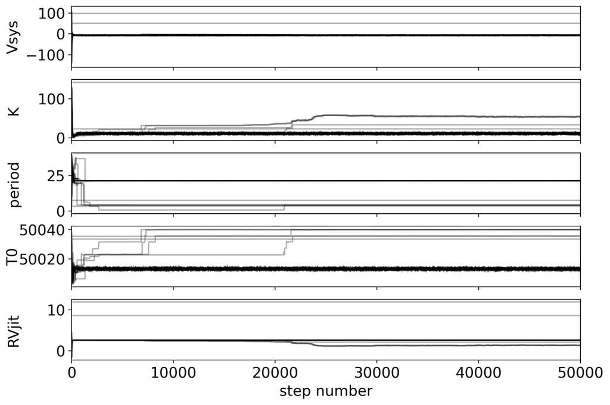

```python
plot_chains(sampler)
```

##### Not good: let's help the convergence

```python
run_phases = 2 # Run 2 phases before final posterior production

sampler = emcee.EnsembleSampler(nwalkers, ndim, log_probability)
for i in range(run_phases):
    print('Running burn-in phase '+str(i+1)+'/'+str(run_phases)+'...')
    if i > 0:
        p0 = p[np.argmax(lnp)] + 1e-8 * np.random.randn(nwalkers, ndim)
        sampler.reset()
    p, lnp, _ = sampler.run_mcmc(p0, nsteps, progress=True, store=False)

print('Running production...')
sampler.reset()
sampler.run_mcmc(p, int(nsteps/2), progress=True)
```

```
Running burn-in phase 1/2...
```

```
Running burn-in phase 2/2...
```

```
Running production...
```

[output not shown]

[output cut: 153 more lines]

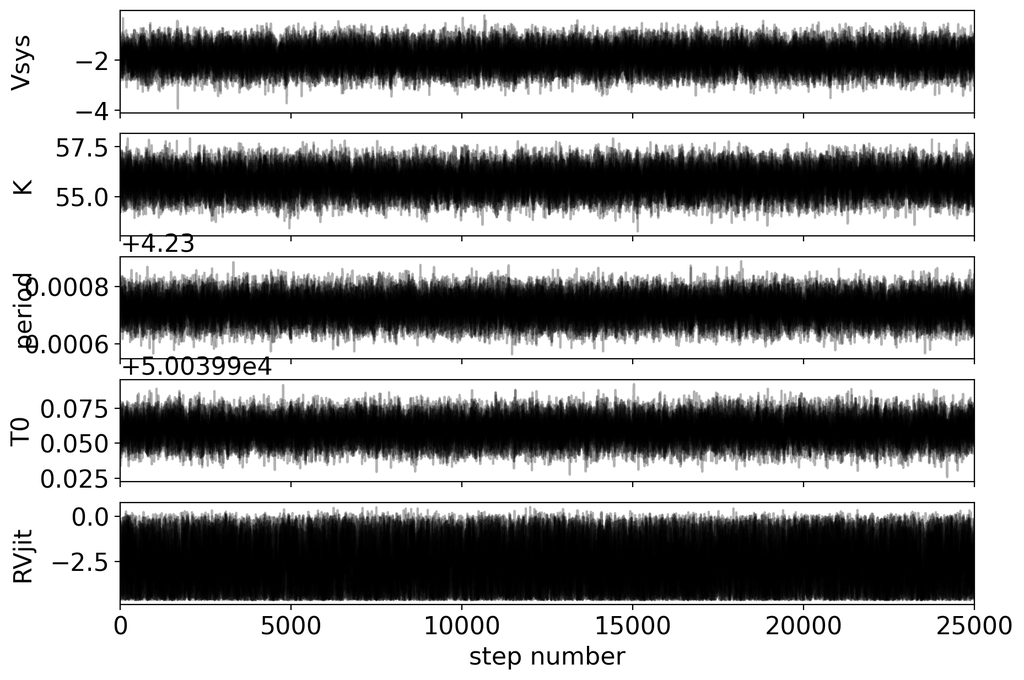

```python
plot_chains(sampler)
```

#### Check convergence (step 7)

```python
table = PrettyTable()

burning = 5000  # Discards the first N steps of each walker

tau = sampler.get_autocorr_time(discard=burning, c=5, tol=10, quiet=True)
print('\n=========================')
print('Autocorrelation times:')
print('=========================')
table.field_names = ["parameter", "tau (in steps)", "Chain length (in multiples of tau)"]
for i, name in enumerate(pnames):
    table.add_row([name, np.round(tau[i],1), np.round((nsteps-burning) / tau[i],1) ])
print(table)
```

```
=========================
Autocorrelation times:
=========================
+-----------+----------------+------------------------------------+
| parameter | tau (in steps) | Chain length (in multiples of tau) |
+-----------+----------------+------------------------------------+
|    Vsys   |      70.2      |               641.0                |
|     K     |      65.7      |               685.3                |
|   period  |      62.3      |               722.8                |
|     T0    |      65.1      |               691.4                |
|   RVjit   |      77.2      |               583.1                |
+-----------+----------------+------------------------------------+
```

#### Check parameter degeneracies (step 8)

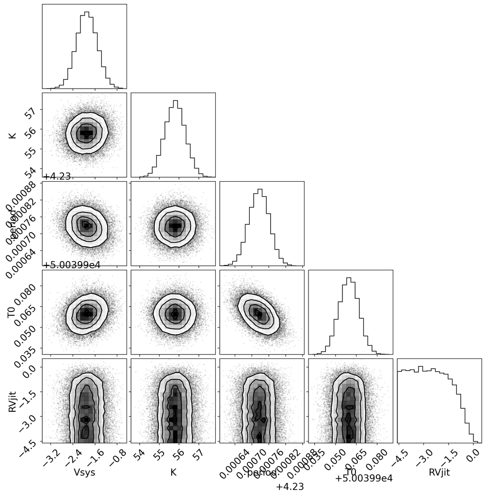

```python
flat_samples = sampler.get_chain(thin=15, flat=True)
fig = corner.corner(flat_samples, labels=pnames)
```

#### Get final parameters and plot inferred results (step 9)

```python
# Median parameters:
table = PrettyTable()
table.field_names = ["parameter", "Value"]

result = [(v[1], v[2]-v[1], v[1]-v[0], v[3])
                for v in zip(*np.percentile(flat_samples, [15.9, 50, 84.1, 95.],axis=0))]
finalp = np.zeros(ndim)
for i in range(ndim):
    finalp[i] = result[i][0]
    out = su.format_error(result[i][0], result[i][2], err_high=result[i][1])
    print(pnames[i]+' = ')
    display(Math(out))
    print('-'*10)
    #table.add_row([pnames[i],display(Math('$'+out+'$'))])

_period = finalp[pnames == 'period']
_T0     = finalp[pnames == 'T0']
phase = ((time - _T0) % _period)/_period
```

```
Vsys =
```

$\displaystyle -1.90^{+0.38}_{-0.37}$

```
----------
K =
```

$\displaystyle 55.79^{+0.52}_{-0.53}$

```
----------
period =
```

$\displaystyle 4.230725^{+0.000036}_{-0.000037}$

```
----------
T0 =
```

$\displaystyle 50039.9596^{+0.0071}_{-0.0073}$

```
----------
RVjit =
```

$\displaystyle -2.7^{+1.4}_{-1.3}$

```python
# ==== Mean & confidence KEPLERIAN model
ymodel_data = []
xmodel_phase = np.linspace(0.,1., 200)
for s in flat_samples[np.random.randint(len(flat_samples), size=1000)]:
    # ===== RV model
    Vsys,K,period,T0,RVjitter = s
    RVmodel = Vsys + K * np.cos(2.*np.pi*xmodel_phase+np.pi/2)
    ymodel_data.append(RVmodel)

ymodel_data 	= np.array(ymodel_data)
mu, sig1 		= ymodel_data.mean(0), 1 * ymodel_data.std(0)
```

```
<ErrorbarContainer object of 3 artists>
```

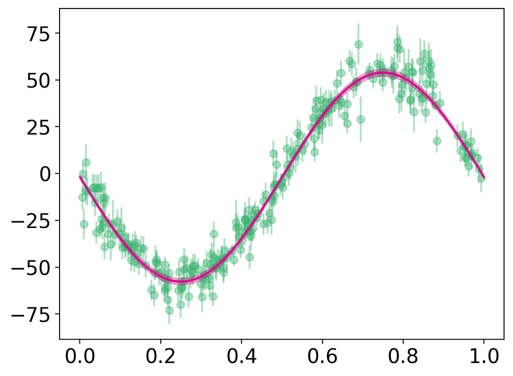

```python
# ==== Plot data & model
plt.plot(xmodel_phase,mu,c='mediumvioletred')
plt.fill_between(xmodel_phase,  mu - sig1,
                                mu + sig1,
                                color='mediumvioletred',alpha=0.3,zorder=-2)
plt.fill_between(xmodel_phase,  mu - 3.*sig1,
                                mu + 3.*sig1,
                                color='mediumvioletred',alpha=0.3,zorder=-3)

plt.errorbar(phase,rv,erv,fmt='o',c='mediumseagreen',zorder=-10,alpha=0.4)
```